# HIV Prevention Outcomes and Data Reliability

Independent R research portfolio project

2026-10-27

# Project overview

I wanted to use public HIV estimates to go beyond comparing the number of new infections across countries. Our World in Data already has useful charts for those trends. For this project, I focused on three questions that require additional calculations or combining indicators: how countries’ infection estimates changed after their observed peaks, whether maternal ART coverage is associated with pediatric HIV outcomes in later years, and whether conclusions about epidemic progress differ when choosing UNAIDS or IHME estimates collected from 1990-2016 and their reported uncertainty.

I used Kenya, South Africa, and Uganda as case studies. These are estimated population-level indicators, not individual patient records. My analyses describe patterns and associations; they do not establish that a particular intervention caused a change in infections.

# Data and preparation

I downloaded the underlying indicators from Our World in Data and checked the original source, units, age group, year coverage, and country labels. Each input file has one row per country and year. I did not average real-world duplicate country-year records: the analysis stops if it finds duplicates so I can investigate them. Missing observations are retained where needed for a data-quality audit, rather than silently filled in.

I used separate files for UNAIDS incidence, IHME incidence, maternal ART coverage, and pediatric infections. Before comparing UNAIDS and IHME, I checked that both incidence files refer to the same age group and annual count measure. The maternal ART variable is a percentage, while pediatric infections are annual counts. These are different units and should not be interpreted as directly comparable quantities.

```r
knitr::kable(quality_overview, caption = 'Rows available and excluded by analysis')
```

Rows available and excluded by analysis

| analysis | total_rows | complete_rows | excluded_rows |
| --- | --- | --- | --- |
| Post-peak (UNAIDS) | 108 | 108 | 0 |
| Maternal ART / pediatric HIV (2-year lag) | 75 | 69 | 6 |
| UNAIDS vs IHME matched 1990–2016 estimates | 81 | 81 | 0 |

# Analysis 1: Post-peak trajectories

**Question:** After each country’s highest observed annual infection estimate, how did subsequent estimates change relative to that peak?

I identified each country’s peak from the available UNAIDS series. I then expressed later estimates as a percentage of that country’s peak and aligned countries by years since peak. This allows me to compare relative trajectories even when peak years and absolute infection counts differ. It does not adjust for population size, and an observed peak can change if the dataset is updated.

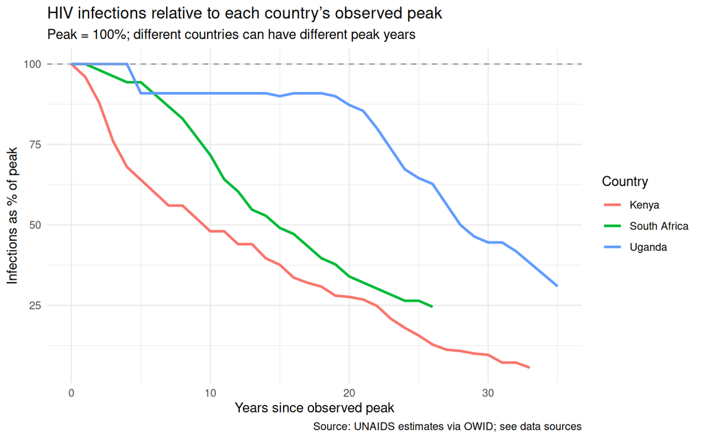

```r
print(p_peak)
```

```r
knitr::kable(post_peak_summary, digits = 1,
             caption = 'Observed peaks and number of post-peak observations')
```

Observed peaks and number of post-peak observations

| country | peak_year | peak_infections | last_year | n_observed |
| --- | --- | --- | --- | --- |
| Kenya | 1992 | 250000 | 2025 | 34 |
| South Africa | 1999 | 530000 | 2025 | 27 |
| Uganda | 1990 | 110000 | 2025 | 36 |

# Analysis 2: Maternal ART and pediatric HIV

**Question:** Is higher ART coverage among pregnant women living with HIV associated with fewer estimated pediatric HIV infections in the same year or in later years?

I matched maternal ART coverage in year *t* to pediatric HIV infections in year *t + L*, where *L* is a lag of zero to three years. The two-year lag is the main example, and the other lags are sensitivity checks. I chose this range to explore whether results depend on timing; it is not a validated biological delay, and the data cannot identify when individual transmissions occurred.

I compare a simple regression with a model that also includes country indicators and a linear outcome-year trend, when enough complete observations are available. I use `log1p()` on pediatric infection counts so the outcome can include zeros. The models describe ecological associations, not causal effects. They also cannot fully account for changes in testing, birth rates, access to care, or other interventions.

```r
knitr::kable(lag_quality, caption = 'Country-year availability and exclusions by lag')
```

Country-year availability and exclusions by lag

| country | lag_years | exclusion_reason | n_country_years |
| --- | --- | --- | --- |
| Kenya | 0 | Included | 25 |
| Kenya | 1 | Included | 24 |
| Kenya | 1 | Pediatric infections missing for outcome year | 1 |
| Kenya | 2 | Included | 23 |
| Kenya | 2 | Pediatric infections missing for outcome year | 2 |
| Kenya | 3 | Included | 22 |
| Kenya | 3 | Pediatric infections missing for outcome year | 3 |
| South Africa | 0 | Included | 25 |
| South Africa | 1 | Included | 24 |
| South Africa | 1 | Pediatric infections missing for outcome year | 1 |
| South Africa | 2 | Included | 23 |
| South Africa | 2 | Pediatric infections missing for outcome year | 2 |
| South Africa | 3 | Included | 22 |
| South Africa | 3 | Pediatric infections missing for outcome year | 3 |
| Uganda | 0 | Included | 25 |
| Uganda | 1 | Included | 24 |
| Uganda | 1 | Pediatric infections missing for outcome year | 1 |
| Uganda | 2 | Included | 23 |
| Uganda | 2 | Pediatric infections missing for outcome year | 2 |
| Uganda | 3 | Included | 22 |
| Uganda | 3 | Pediatric infections missing for outcome year | 3 |

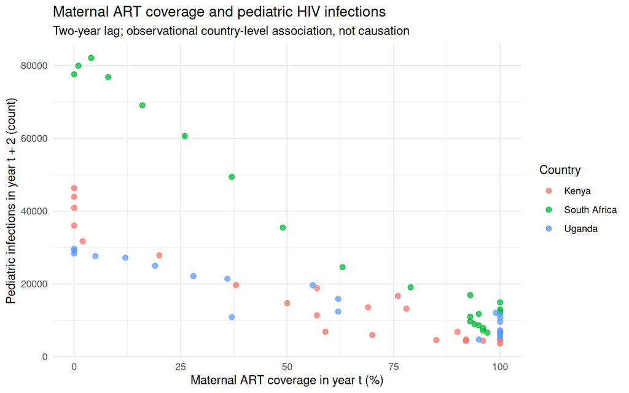

```r
print(p_art)
```

```r
if (nrow(model_results) > 0) {
  knitr::kable(model_results, digits = 4,
               caption = 'Unadjusted and adjusted regression coefficients')
} else {
  cat('The available complete data did not meet the prespecified conditions for regression.')
}
```

Unadjusted and adjusted regression coefficients

| model | term | estimate | std_error | p_value | n |
| --- | --- | --- | --- | --- | --- |
| Unadjusted | (Intercept) | 10.7309 | 0.1028 | 0.0000 | 69 |
| Unadjusted | art_percent | -0.0182 | 0.0014 | 0.0000 | 69 |
| Country + linear year adjusted | (Intercept) | 187.6480 | 17.6690 | 0.0000 | 69 |
| Country + linear year adjusted | art_percent | -0.0050 | 0.0015 | 0.0017 | 69 |
| Country + linear year adjusted | countrySouth Africa | 0.6179 | 0.0606 | 0.0000 | 69 |
| Country + linear year adjusted | countryUganda | 0.1180 | 0.0593 | 0.0511 | 69 |
| Country + linear year adjusted | outcome_year | -0.0884 | 0.0088 | 0.0000 | 69 |

# Analysis 3: Source sensitivity and estimation uncertainty (1990–2016)

**Research question:** Do UNAIDS and IHME estimates lead to consistent conclusions about HIV epidemic progress in Kenya, South Africa, and Uganda from 1990–2016, and how does estimation uncertainty affect our confidence in those conclusions?

I compared the same all-age, both-sex **annual counts** of new HIV infections from the UNAIDS 2026 estimates workbook and IHME exports. I restricted both sources to 1990–2016, the common period covered by the downloaded files. I combined the three IHME country CSVs in R, and retained the estimate, lower bound, and upper bound from each source. The analysis requires matching country and calendar year; it does not impute missing estimates. Because the two organizations use different estimation methods, differences do not establish which source is correct.

## Data quality and exclusions

I first checked the expected 27 country-years per country and counted complete pairs of point estimates and uncertainty bounds. The table below makes missingness explicit instead of silently dropping unmatched observations.

```r
knitr::kable(quality, caption='Matched years and completeness of source estimates, 1990–2016')
```

Matched years and completeness of source estimates, 1990–2016

| country | expected_years | paired_point_years | paired_with_bounds | missing_point_years |
| --- | --- | --- | --- | --- |
| Kenya | 27 | 27 | 27 | 0 |
| South Africa | 27 | 27 | 27 | 0 |
| Uganda | 27 | 27 | 27 | 0 |

```r
knitr::kable(exclusions, caption='Reasons country-years were excluded from paired comparisons')
```

Reasons country-years were excluded from paired comparisons

| country | reason | years |
| --- | --- | --- |
| Kenya | Complete | 27 |
| South Africa | Complete | 27 |
| Uganda | Complete | 27 |

## Stage 1: Comparing epidemic progress

For each source and country, I identified the year with the largest estimated number of new infections **within 1990–2016**. I then calculated the percentage change from that source-specific peak to 2016 and the average annual change in estimated infection counts over the same interval. The average annual change is an endpoint-based descriptive measure, not a regression slope. When two years have equal peak estimates, the earlier year is selected. If a peak occurs in 2016, post-peak change is undefined rather than reported as zero.

```r
knitr::kable(progress, digits=2,
             caption='Source-specific observed peaks and changes through 2016')
```

Source-specific observed peaks and changes through 2016

| country | source | n_years | peak_year | peak_value | endpoint_value | elapsed_years | peak_to_2016_pct | annual_change_count |
| --- | --- | --- | --- | --- | --- | --- | --- | --- |
| Kenya | IHME | 27 | 1993 | 254186.7 | 99052.16 | 23 | -61.03 | -6744.98 |
| Kenya | UNAIDS | 27 | 1992 | 250000.0 | 45000.00 | 24 | -82.00 | -8541.67 |
| South Africa | IHME | 27 | 1999 | 779932.7 | 268514.59 | 17 | -65.57 | -30083.42 |
| South Africa | UNAIDS | 27 | 1999 | 530000.0 | 230000.00 | 17 | -56.60 | -17647.06 |
| Uganda | IHME | 27 | 1990 | 200587.4 | 77541.91 | 26 | -61.34 | -4732.52 |
| Uganda | UNAIDS | 27 | 1990 | 110000.0 | 69000.00 | 26 | -37.27 | -1576.92 |

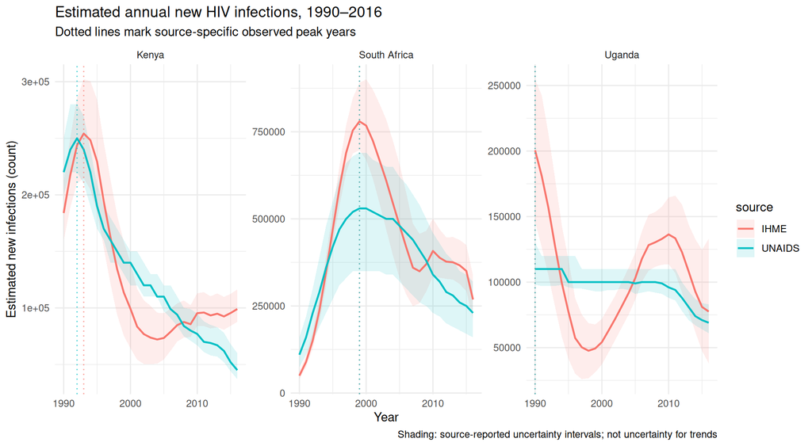

```r
print(p_trajectories)
```

## Stage 2: Evaluating estimation uncertainty

I compared the reported lower and upper bounds for each matched year and calculated how often the two reported intervals overlap. I also recorded whether either source’s point estimate falls inside the other source’s interval, and calculated each interval’s width relative to its point estimate. These summaries describe the uncertainty reported for **individual annual estimates**. Interval overlap is not a hypothesis test, and the two sources may use different uncertainty methods or coverage conventions.

```r
knitr::kable(uncertainty, digits=1,
             caption='Descriptive uncertainty comparisons across matched years')
```

Descriptive uncertainty comparisons across matched years

| country | n_interval_pairs | n_overlap | pct_overlap | n_unaids_inside_ihme | n_ihme_inside_unaids | median_unaids_width_pct | median_ihme_width_pct |
| --- | --- | --- | --- | --- | --- | --- | --- |
| Kenya | 27 | 19 | 70.4 | 14 | 6 | 25.0 | 38.6 |
| South Africa | 27 | 23 | 85.2 | 10 | 17 | 65.9 | 35.8 |
| Uganda | 27 | 15 | 55.6 | 11 | 4 | 20.0 | 61.6 |

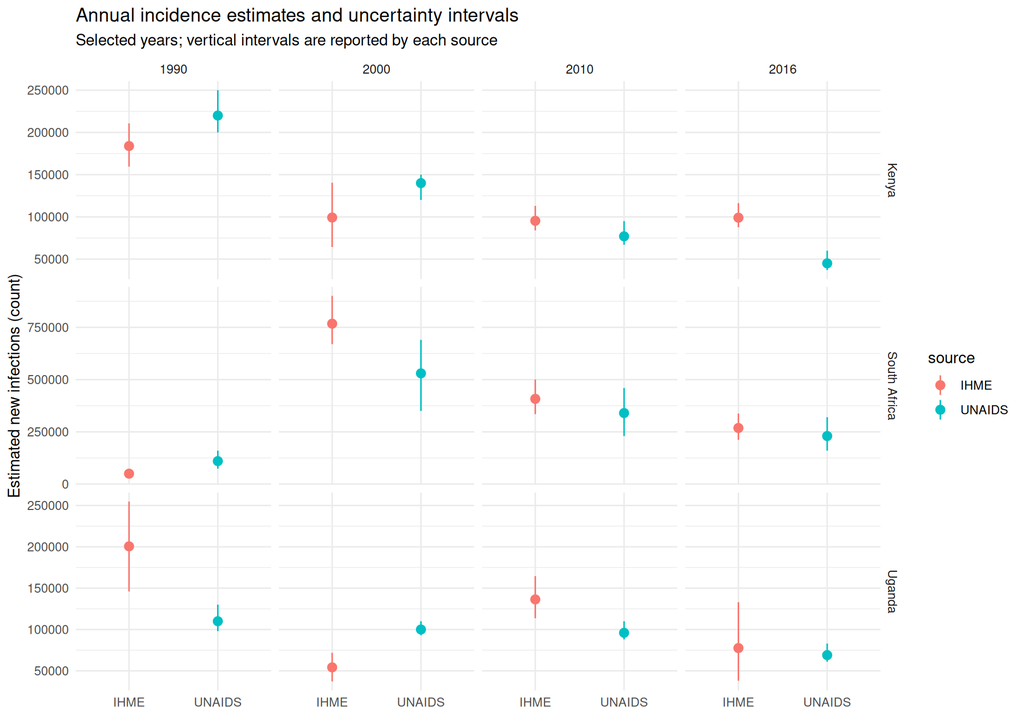

```r
print(p_intervals)
```

## Stage 3: Testing sensitivity of conclusions

I repeated the **same calculations** using each source separately. I then compared peak years, the direction and magnitude of peak-to-2016 change, and country rankings by percentage decline. This asks whether the choice of source changes a substantive conclusion rather than merely whether point estimates differ.

```r
knitr::kable(comparison, digits=2,
             caption='Differences in conclusions between UNAIDS and IHME')
```

Differences in conclusions between UNAIDS and IHME

| country | peak_year_IHME | peak_year_UNAIDS | peak_to_2016_pct_IHME | peak_to_2016_pct_UNAIDS | annual_change_count_IHME | annual_change_count_UNAIDS | peak_year_difference | pct_change_difference | same_direction |
| --- | --- | --- | --- | --- | --- | --- | --- | --- | --- |
| Kenya | 1993 | 1992 | -61.03 | -82.00 | -6744.98 | -8541.67 | -1 | -20.97 | TRUE |
| South Africa | 1999 | 1999 | -65.57 | -56.60 | -30083.42 | -17647.06 | 0 | 8.97 | TRUE |
| Uganda | 1990 | 1990 | -61.34 | -37.27 | -4732.52 | -1576.92 | 0 | 24.07 | TRUE |

```r
knitr::kable(ranking,
             caption='Country rankings by source-specific peak-to-2016 change')
```

Country rankings by source-specific peak-to-2016 change

| country | IHME | UNAIDS | same_rank |
| --- | --- | --- | --- |
| Kenya | 3 | 1 | FALSE |
| South Africa | 1 | 2 | FALSE |
| Uganda | 2 | 3 | FALSE |

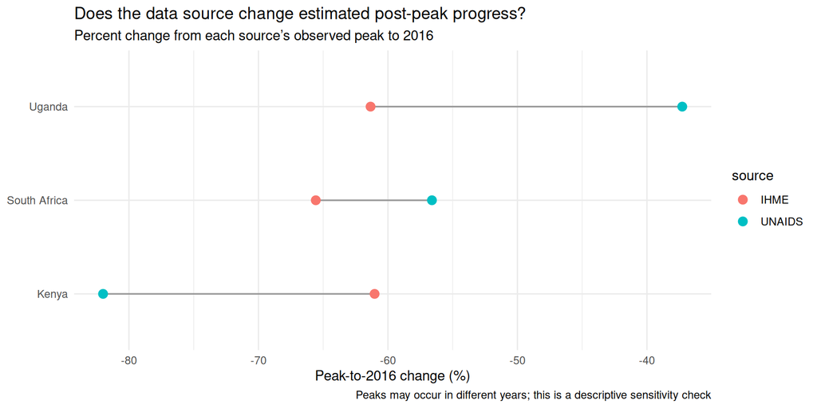

```r
print(p_sensitivity)
```

To explore how sensitive the **direction** of change is to reported endpoint ranges, I also calculated an illustrative stress test: the smallest and largest percentage changes obtained by combining the reported bounds at the selected peak year and in 2016. The peak year is held fixed. These extremes are not joint probability intervals and **must not be presented as confidence or uncertainty intervals for the decline**. Without time-correlated model draws, the uncertainty of a peak year, change statistic, or regression slope cannot be estimated reliably from annual bounds alone.

```r
knitr::kable(endpoint_bounds |> select(country,source,stress_smallest_pct,
                                      stress_largest_pct,stress_sign_stable),
             digits=1, caption='Illustrative endpoint-bound sensitivity (not a confidence interval)')
```

Illustrative endpoint-bound sensitivity (not a confidence interval)

| country | source | stress_smallest_pct | stress_largest_pct | stress_sign_stable |
| --- | --- | --- | --- | --- |
| Kenya | UNAIDS | -86.8 | -72.7 | Decline across endpoints |
| South Africa | UNAIDS | -76.8 | -8.6 | Decline across endpoints |
| Uganda | UNAIDS | -53.1 | -15.3 | Decline across endpoints |
| Kenya | IHME | -71.0 | -45.8 | Decline across endpoints |
| South Africa | IHME | -76.2 | -51.6 | Decline across endpoints |
| Uganda | IHME | -85.1 | -8.9 | Decline across endpoints |

# AI-assisted code validation

I also evaluated an AI-generated R approach for calculating percentage change between 1990 and 2024. My first synthetic test included duplicate observations for one country-year. The original reshaping approach retained an observation-count column, which could split one country into multiple rows. I revised the workflow to keep diagnostic counts separate from the values being reshaped and tested missing baselines, zero baselines, duplicate observations, and a missing baseline year.

The synthetic tests are in `ai_validation.R`. They are separate from the real epidemiological analyses because I intentionally created edge cases that should not be assumed to occur in the OWID source files. I recorded the AI assistance and checked the expected outputs independently.

```r
source('ai_validation.R')
```

```
## # A tibble: 5 × 6
##   country expected_change infections_1990 infections_2024 percent_change passed
##   <chr>             <dbl>           <dbl>           <dbl>          <dbl> <lgl>
## 1 A                   -25             100              75            -25 TRUE
## 2 B                    NA               0              50             NA TRUE
## 3 C                    NA              NA              30             NA TRUE
## 4 D                   -15             100              85            -15 TRUE
## 5 E                    NA              NA              30             NA TRUE
```

```r
knitr::kable(checks, caption = 'Synthetic test results for the corrected calculation')
```

Synthetic test results for the corrected calculation

| country | expected_change | infections_1990 | infections_2024 | percent_change | passed |
| --- | --- | --- | --- | --- | --- |
| A | -25 | 100 | 75 | -25 | TRUE |
| B | NA | 0 | 50 | NA | TRUE |
| C | NA | NA | 30 | NA | TRUE |
| D | -15 | 100 | 85 | -15 | TRUE |
| E | NA | NA | 30 | NA | TRUE |

# Limitations and next steps

The main limitations are ecological inference, estimated rather than observed infection totals, possible differences between source definitions, unequal data availability across indicators, and the use of absolute pediatric infection counts rather than a validated mother-to-child transmission rate. Country and year adjustments do not eliminate confounding. I would not use these results to make clinical recommendations.

A next step would be to obtain joint uncertainty draws, population or birth denominators, and additional prevention indicators where the definitions and coverage are compatible. The companion Shiny app allows users to explore the descriptive results and see how many observations contribute to each view.

# Data sources and reproducibility

- Our World in Data HIV/AIDS topic page: https://ourworldindata.org/hiv-aids
- Underlying source estimates: UNAIDS and IHME; exact indicator URLs, access dates, units, and licenses should be entered in `data/SOURCES.md` before publishing.
- Run `analysis.R` to regenerate figures and tables. Run `ai_validation.R` to check synthetic cases. Run `app.R` to launch the dashboard.